# Imports

```python
#ignore unless on colab

from google.colab import drive
drive.mount('/content/drive')
```

```python
#ignore unless on colab

import nltk
nltk.download('stopwords')
nltk.download('punkt')
!pip install contractions
!pip install translators --upgrade
```

```python
#main imports

import nltk
from nltk.tokenize import RegexpTokenizer
from nltk import word_tokenize
from nltk.probability import FreqDist
from nltk.stem import PorterStemmer
from nltk.corpus import stopwords

from sklearn.feature_extraction.text import CountVectorizer
from sklearn.model_selection import train_test_split
from sklearn import linear_model
from sklearn import metrics
from sklearn.model_selection import GridSearchCV
from sklearn.preprocessing import LabelEncoder
from sklearn.feature_extraction.text import TfidfVectorizer
from imblearn.over_sampling import SMOTE

import matplotlib.pyplot as plt

from collections import defaultdict
from collections import Counter
import contractions
import csv
import pandas as pd
import numpy as np
import pickle
```

# Text Parsing

This section parses the initial dataset and applies data preprocessing techniques including stemming, stopword removal, substituting contractions, and tokenization. We then choose specific features to focus on in the dataset, extract them, and convert them to Bag of Words and Tfidf feature vectorizations. The dataset is also duplicated and augumented using SMOTE to account for the imbalance fake and real job postings.

```python
#set up tools and variables to properly process and store raw text

ps = PorterStemmer()
stop_words = set(stopwords.words('english'))
documents = []
Y = []
```

### Using Pandas Dataframe (should be faster with larger dataset)

```python
#read and process job posting dataset into pandas dataframe

print('\nLoading the file: \n', 'input/fake_job_postings.csv')
df = pd.read_csv('input/fake_job_postings.csv')
print('Loaded.')

Y = df["fraudulent"]

tokenizer = RegexpTokenizer('\w+')
# fill in null
for col in ["title", "company_profile", "description", "requirements"]:
  df[col] = df[col].fillna("")
  print("stemming", col)

  #apply text processing to each column
  df['stem_'+ col] = df.apply(lambda row: [ps.stem(word.lower()) for word in tokenizer.tokenize(contractions.fix(row[col])) if not word.lower() in stop_words], axis=1)
```

[output not shown]

```python
#check columns for features

df.head(0)
```

|  | job_id | title | location | department | salary_range | company_profile | description | requirements | benefits | telecommuting | ... | employment_type | required_experience | required_education | industry | function | fraudulent | stem_title | stem_company_profile | stem_description | stem_requirements |
| --- | --- | --- | --- | --- | --- | --- | --- | --- | --- | --- | --- | --- | --- | --- | --- | --- | --- | --- | --- | --- | --- |

0 rows × 22 columns

```python
# combining stemmed tokens into main dataset
df['documents'] = df['stem_title'] + df['stem_company_profile'] + df['stem_description'] + df['stem_requirements']
df['documents'] = df['documents'].str.join(' ')
df['documents']
```

```
0        market intern food52 creat groundbreak award w...
1        custom servic cloud video product 90 second wo...
2        commiss machineri assist cma valor servic prov...
3        account execut washington dc passion improv qu...
4        bill review manag spotsourc solut llc global h...
                               ...
17875    account director distribut vend look awesom ne...
17876    payrol account weblinc e commerc platform serv...
17877    project cost control staff engin cost control ...
17878    graphic design nemsia studio look experienc vi...
17879    web applic develop vend look awesom new talent...
Name: documents, Length: 17880, dtype: object
```

```python
#vectorize word tokens for use in model

vectorizer = CountVectorizer(stop_words='english', min_df=0.01, ngram_range=(1,3))
X = vectorizer.fit_transform(df['documents']) #vectorize feature dataset
print('Feature data shape: ', X.shape, '\nLabel data shape:', Y.shape)
```

[output not shown]

### Load from pickle

```python
#alternatively load dataset and vectorizers from previous experimentation

df = pd.read_pickle('generated/dataframe.pkl')
vectorizer = pickle.load(open('generated/vectorizer.pkl', 'rb'))
Tfidf_vect = pickle.load(open('generated/Tfidf_vect.pkl', 'rb'))
X = pickle.load(open('generated/X.pkl', 'rb'))
Y = df["fraudulent"]
print('Feature data shape: ', X.shape)
```

```
Feature data shape:  (17880, 3778)
```

### Generate datasets

```python
#use SMOTE to augument fake job class data for balanced dataset

sm = SMOTE(random_state=0)
X_res, Y_res = sm.fit_resample(X,Y)
print('Resampled data shape: ', X_res.shape, Y_res.shape)
print('Resampled data class balance: %s' % Counter(Y_res))

#split into training and testing datasets for later
X_res_train, X_res_test, Y_res_train, Y_res_test = train_test_split(X_res, Y_res, test_size=0.3)
```

```
Resampled data shape:  (34028, 3778) (34028,)
Resampled data class balance: Counter({0: 17014, 1: 17014})
```

```python
#Use tfidf vectorizer to convert raw dataset into tfidf feature model and associated labels

X_train, X_test, Y_train, Y_test = train_test_split(df['documents'], Y, test_size=0.5)

#encode labels
Encoder = LabelEncoder()
Train_Y_Tfidf = Encoder.fit_transform(Y_train)
Test_Y_Tfidf = Encoder.fit_transform(Y_test)

#convert dataset to tfidf feature representation
Tfidf_vect = TfidfVectorizer()
Tfidf_vect.fit(df['documents'])
Train_X_Tfidf = Tfidf_vect.transform(X_train)
Test_X_Tfidf = Tfidf_vect.transform(X_test)
```

```python
#split base dataset into training and testing data

X_train, X_test, Y_train, Y_test = train_test_split(X, Y, test_size=0.5)
```

### Dump to pickle

```python
#store time consuming cells in pickle files to load later

df.to_pickle('generated/dataframe.pkl')
pickle.dump(vectorizer, open('generated/vectorizer.pkl', 'wb'))
pickle.dump(X, open('generated/X.pkl', 'wb'))
pickle.dump(Tfidf_vect, open('generated/Tfidf_vect.pkl', 'wb'))
```

#### Language translation data augumentation

##### Unused

ends up taking too long, likely because library uses outside server that rate limits requests

originally meant to raw data to other language and back as a method of generating "new" data to augument dataset as solution for imbalance in class distribution

```python
import translators as ts
import translators.server as tss
import random

language_list = ['cy', 'zh', 'ru', 'fr', 'ja', 'es', 'it', 'de', 'ko', 'el', 'ar']

#extract feature relevant dataframe for fraudulent job postings
fake_df = df[df.fraudulent == 1]
fake_df['tr_documents'] = fake_df['title'] + fake_df['company_profile'] + fake_df['description'] + fake_df['requirements']
fake_df = fake_df['tr_documents'].str.join('')

for i in range(len(fake_df['tr_documents'])):
    language = random.choice(language_list)
    entry = fake_df['tr_documents'][i]

    #translate to random different language and back to generate similar entry
    entry = tss.google(entry, from_language='en', to_language=language)
    entry = tss.google(entry, from_language=language, to_language='en')
    entry = ' '.join([ps.stem(word.lower()) for word in tokenizer.tokenize(contractions.fix(entry)) if not word.lower() in stop_words])
    df['tr_documents'][i] = entry
```

# Analysis

Data analysis to attempt to find important features that strongly correlate with fraudulency.

For non-boolean features, we found the top 10 most commonly occuring values associated with fraudulency, then generated a bar plot of each feature value's percent fraudulency to compare.

A function is also created to uniformly test each generated model for accuracy according to various metrics.

```python
import seaborn as sns
```

```python
#dataset has large amounts of null values

df.isna().sum()
```

```
job_id                      0
title                       0
location                  346
department              11547
salary_range            15012
company_profile             0
description                 0
requirements                0
benefits                 7210
telecommuting               0
has_company_logo            0
has_questions               0
employment_type          3471
required_experience      7050
required_education       8105
industry                 4903
function                 6455
fraudulent                  0
stem_title                  0
stem_company_profile        0
stem_description            0
stem_requirements           0
documents                   0
dtype: int64
```

```python
#get most common fraudulent values and percentage of original dataframe for selected features
test_df = df[['location', 'department', 'salary_range', 'employment_type', 'required_experience', 'industry', 'fraudulent']]
feature_fraud_cor = {} #dict with feature names as keys and two-tuple values of (most common fraudulent values, percentage of original dataset)
fraud_test_df = test_df[test_df.fraudulent == 1] #get fraudulent subset of original dataframe
for col in ['location', 'department', 'salary_range', 'employment_type', 'required_experience', 'industry']:
    n_largest_fraud = fraud_test_df[col].value_counts().nlargest(10) #top 10 most common feature values in fraudulent subset
    n_largest_df = test_df[test_df[col].isin(n_largest_fraud.index)] #number of occurences of each feature value in original df
    feature_fraud_cor[col] = (n_largest_fraud, n_largest_fraud.div(n_largest_df[col].value_counts()).sort_values(ascending=False))
```

```
US, TX, Houston        92
AU, NSW, Sydney        31
US, ,                  28
US, CA, Bakersfield    24
US, CA, Los Angeles    23
US, CA, San Mateo      22
US, NY, New York       20
US, CA, San Jose       14
US, TX, AUSTIN         14
US, TX, DALLAS         12
Name: location, dtype: int64
```

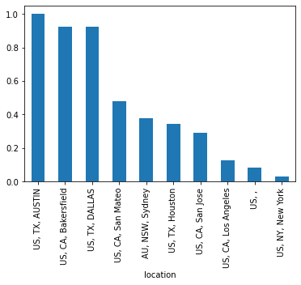

```python
print(feature_fraud_cor['location'][0]) #print most commonly occuring fraudulent feature values
feature_fraud_cor['location'][1].plot.bar(xlabel='location') #generate bar plot of percentage of original dataset for each value
```

```
Engineering                46
Clerical                   27
Oil & Energy               24
Information Technology     15
Administrative             14
Customer Service           14
Information Technology     12
Sales                      12
Engineering                 9
admin                       7
Name: department, dtype: int64
```

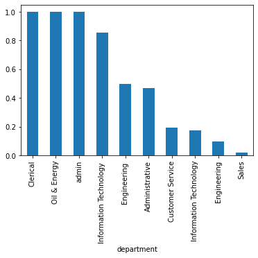

```python
print(feature_fraud_cor['department'][0])
feature_fraud_cor['department'][1].plot.bar(xlabel='department')
```

```
7200-1380000     10
30000-50000       8
250000-500000     7
28000-32000       6
35000-40000       6
23000-28000       5
21-63000          5
1000-2000         5
70000-80000       5
25000-30000       5
Name: salary_range, dtype: int64
```

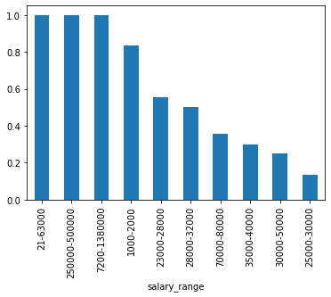

```python
print(feature_fraud_cor['salary_range'][0])
feature_fraud_cor['salary_range'][1].plot.bar(xlabel='salary_range')
```

```
Full-time    490
Part-time     74
Contract      44
Other         15
Temporary      2
Name: employment_type, dtype: int64
```

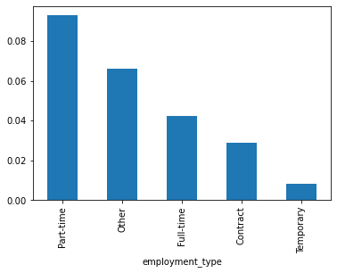

```python
print(feature_fraud_cor['employment_type'][0])
feature_fraud_cor['employment_type'][1].plot.bar(xlabel='employment_type')
```

```
Entry level         179
Mid-Senior level    113
Not Applicable       60
Associate            42
Director             17
Executive            10
Internship           10
Name: required_experience, dtype: int64
```

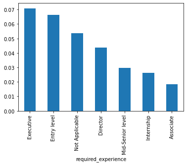

```python
print(feature_fraud_cor['required_experience'][0])
feature_fraud_cor['required_experience'][1].plot.bar(xlabel='required_experience')
```

```
Oil & Energy                           109
Accounting                              57
Hospital & Health Care                  51
Marketing and Advertising               45
Financial Services                      35
Information Technology and Services     32
Telecommunications                      26
Real Estate                             24
Consumer Services                       24
Leisure, Travel & Tourism               21
Name: industry, dtype: int64
```

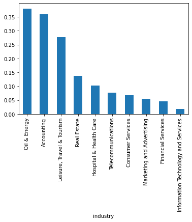

```python
print(feature_fraud_cor['industry'][0])
feature_fraud_cor['industry'][1].plot.bar(xlabel='industry')
```

```python
#attempt to correlate boolean features with fraudulency to see if there is any pattern

boolean_df = df[['telecommuting', 'has_company_logo', 'has_questions', 'fraudulent']] #subset of boolean features
real_df = boolean_df[boolean_df.fraudulent == 0] #boolean features on real jobs
fake_df = boolean_df[boolean_df.fraudulent != 0] #boolean features on fake jobs
```

```
                    job_id  telecommuting  has_company_logo  has_questions  \
job_id            1.000000      -0.004559         -0.014539      -0.087025
telecommuting    -0.004559       1.000000         -0.019836       0.020345
has_company_logo -0.014539      -0.019836          1.000000       0.233932
has_questions    -0.087025       0.020345          0.233932       1.000000
fraudulent        0.079872       0.034523         -0.261971      -0.091627

                  fraudulent
job_id              0.079872
telecommuting       0.034523
has_company_logo   -0.261971
has_questions      -0.091627
fraudulent          1.000000
```

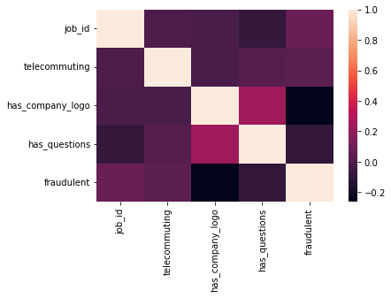

```python
corr = df.corr() #correlation matrix of all boolean features and fraudulency label
sns.heatmap(corr)
print(corr)
```

```
                  telecommuting  has_company_logo  has_questions  fraudulent
telecommuting          1.000000         -0.012029       0.029234    0.036902
has_company_logo      -0.012029          1.000000       0.208259    0.003602
has_questions          0.029234          0.208259       1.000000    0.007635
fraudulent             0.036902          0.003602       0.007635    1.000000
```

```
C:\Users\Patrick Xu\AppData\Local\Temp\ipykernel_24204\562361355.py:5: FutureWarning: The frame.append method is deprecated and will be removed from pandas in a future version. Use pandas.concat instead.
  real_df = real_df.append(fake_nan_row, ignore_index=True)
```

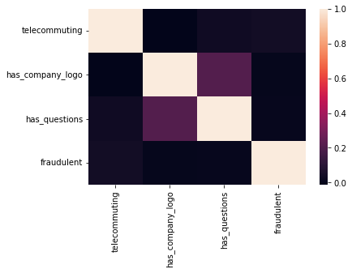

```python
#extra row added to prevent zero division since all fraudulency entries are 0
fake_nan_row = pd.Series({'telecommuting':1, 'has_company_logo':1, 'has_questions':1, 'fraudulent':1})
real_df = real_df.append(fake_nan_row, ignore_index=True)

real_corr = real_df.corr() #correlation matrix of boolean features and real jobs
sns.heatmap(real_corr)
print(real_corr)
```

```
                  telecommuting  has_company_logo  has_questions  fraudulent
telecommuting          1.000000          0.001031      -0.062852    0.009593
has_company_logo       0.001031          1.000000       0.409411    0.023655
has_questions         -0.062852          0.409411       1.000000    0.021631
fraudulent             0.009593          0.023655       0.021631    1.000000
```

```
C:\Users\Patrick Xu\AppData\Local\Temp\ipykernel_24204\2501311613.py:5: FutureWarning: The frame.append method is deprecated and will be removed from pandas in a future version. Use pandas.concat instead.
  fake_df = fake_df.append(real_nan_row, ignore_index=True)
```

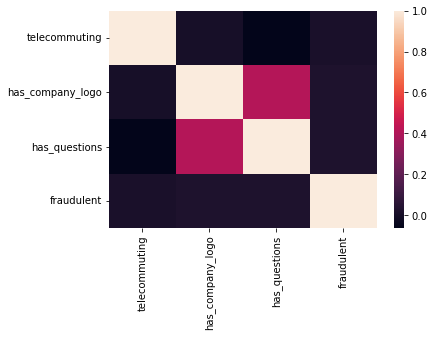

```python
#extra row added to prevent zero division since all fraudulency entries are 1
real_nan_row = pd.Series({'telecommuting':0, 'has_company_logo':0, 'has_questions':0, 'fraudulent':0})
fake_df = fake_df.append(real_nan_row, ignore_index=True)

fake_corr = fake_df.corr() #correlation matrix of boolean features and fake jobs
sns.heatmap(fake_corr)
print(fake_corr)
```

```python
#function to output model score according to various metrics
#takes a model and train test split of data to run model predictions on
#returns model predictions and scoring on each metric as dicts

def model_score(model, X_train, X_test, Y_train, Y_test):
    training_predictions = model.predict(X_train) #evaluate training accuracy

    train_accuracy = metrics.accuracy_score(Y_train, training_predictions)
    print('Training accuracy: %.2f' % train_accuracy)

    test_predictions = model.predict(X_test) #evaluate testing accuracy

    test_accuracy = metrics.accuracy_score(Y_test, test_predictions)
    print('Testing accuracy: %.2f' % test_accuracy)

    test_predict_proba = model.predict_proba(X_test)[:,1] #evaluate testing probabilities

    test_auc_score = metrics.roc_auc_score(Y_test, test_predict_proba)
    print('AUC value: %.2f' % test_auc_score)

    bal_score = metrics.balanced_accuracy_score(Y_test, test_predictions) #evaluate balanced score (average of recall scores)
    print('Balanced score: %.2f' % bal_score)

    precision = metrics.precision_score(Y_test, test_predictions) #evaluate precision score
    print('Precision: %.2f' % precision)

    k_predictions = model.predict(X_test[:100]) #evaluate precision score on 100 entries
    k_precision = metrics.precision_score(Y_test[:100], k_predictions)
    print('Precision over 100 entries: %.2f' % k_precision)

    recall = metrics.recall_score(Y_test, test_predictions) #evaluate recall score
    print('Recall: %.2f' % recall)

    f1 = metrics.f1_score(Y_test, test_predictions) #evaluate f1 score
    print('F1: %.2f' % f1)

    #save predictions and scores to return
    predictions = {
        'training': training_predictions,
        'testing:': test_predictions,
        'testing_proba': test_predict_proba,
        'k': k_predictions
    }

    scores = {
        'training': train_accuracy,
        'testing': test_accuracy,
        'auc': test_auc_score,
        'balanced': bal_score,
        'precision': precision,
        'k_precision': k_precision,
        'recall': recall,
        'f1': f1
    }

    return predictions, scores
```

# Logistic Regression

This section focuses on the baseline logistic regression model, experimenting with hyperparameter tuning, different feature representations, and imbalanced vs balanced dataset to compare each adjustment's effectiveness on model accuracy.

## Hyperparameter Tuning

This section tunes hyperparameters for logistic regression model using grid search on created hyperparameter matrix.

```python
#establish hyperparameter matrix to be search through

c_space = np.logspace(-1, 3, 5).tolist()
solvers = ['lbfgs','newton-cg','liblinear','sag','saga']
param_grid = {'C': c_space, 'solver': solvers}
param_grid
```

```python
#run gridsearchCV to find best combination of hyperparameters over base logistic regression model

X_train, X_test, Y_train, Y_test = train_test_split(X, Y, test_size=0.9)
logreg = linear_model.LogisticRegression(fit_intercept=True, max_iter=10000)
log_grid = GridSearchCV(logreg, param_grid=param_grid, cv=3)
log_grid.fit(X_train, Y_train)
```

```python
#extract optimal hyperparameter combination

logreg_best_c, logreg_best_solver = log_grid.best_params_.values()
print('c:', logreg_best_c, '\nsolver:', logreg_best_solver, '\nscore:', log_grid.best_score_)
```

### Already tuned

Tuned hyperparameters previously, initializing to optimized values

```python
logreg_best_c = 0.1
logreg_best_solver = 'liblinear'
```

## Training

Train multiple logistic regression models using different combinations of various features. We compare model accuracy while adjusting optimal hyperparameters, usage of BOW vs tfidf feature models, and imbalanced vs augumented balanced dataset.

```python
#regenerate tfidf feature representation and BOW dataset

X_train, X_test, Y_train, Y_test = train_test_split(df['documents'], Y, test_size=0.3)
Encoder = LabelEncoder()
Train_Y_Tfidf = Encoder.fit_transform(Y_train)
Test_Y_Tfidf = Encoder.fit_transform(Y_test)
Tfidf_vect = TfidfVectorizer()
Tfidf_vect.fit(df['documents'])
Train_X_Tfidf = Tfidf_vect.transform(X_train)
Test_X_Tfidf = Tfidf_vect.transform(X_test)

X_train, X_test, Y_train, Y_test = train_test_split(X, Y, test_size=0.3)
```

```python
#train logistic regression model using optimized hyperparameters

logreg_model_tuned = linear_model.LogisticRegression(C=logreg_best_c, penalty='l2', solver=logreg_best_solver, fit_intercept=True, max_iter=10000)
logreg_model_tuned.fit(X_train, Y_train)
```

```
LogisticRegression(C=0.1, max_iter=10000, solver='liblinear')
```

```python
#train base logistic regression model

logreg_model = linear_model.LogisticRegression(penalty='l2', fit_intercept=True, max_iter=10000)
logreg_model.fit(X_train, Y_train)
```

```
LogisticRegression(max_iter=10000)
```

```python
#train logistic regression model using tfidf feature set and optimized hyperparameters

logreg_model_tuned_tfidf = linear_model.LogisticRegression(C=logreg_best_c, penalty='l2', solver=logreg_best_solver, fit_intercept=True, max_iter=10000)
logreg_model_tuned_tfidf.fit(Train_X_Tfidf, Train_Y_Tfidf)
```

```
LogisticRegression(C=0.1, max_iter=10000, solver='liblinear')
```

```python
#train base logistic regression model using tfidf feature set

logreg_model_tfidf = linear_model.LogisticRegression(penalty='l2', fit_intercept=True, max_iter=10000)
logreg_model_tfidf.fit(Train_X_Tfidf, Train_Y_Tfidf)
```

```
LogisticRegression(max_iter=10000)
```

```python
#train logistic regression model using augumented dataset and optimized hyperparameters

logreg_res_model_tuned = linear_model.LogisticRegression(C=logreg_best_c, penalty='l2', solver=logreg_best_solver, fit_intercept=True, max_iter=10000)
logreg_res_model_tuned.fit(X_res_train, Y_res_train)
```

```
LogisticRegression(C=0.1, max_iter=10000, solver='liblinear')
```

```python
#train base logistic regression model using augumented dataset

logreg_res_model = linear_model.LogisticRegression(penalty='l2', fit_intercept=True, max_iter=10000)
logreg_res_model.fit(X_res_train, Y_res_train)
```

```
LogisticRegression(max_iter=10000)
```

### Load from pickle

Load previously trained models and scores if available

```python
logreg_model_tuned = pickle.load(open('generated/logistic_model_tuned.pkl', 'rb'))
logreg_model = pickle.load(open('generated/logistic_model.pkl', 'rb'))
logreg_model_tuned_tfidf = pickle.load(open('generated/logistic_model_tuned_tfidf.pkl', 'rb'))
logreg_model_tfidf = pickle.load(open('generated/logistic_model_tfidf.pkl', 'rb'))
logreg_res_model_tuned = pickle.load(open('generated/logistic_res_model_tuned.pkl', 'rb'))
logreg_res_model = pickle.load(open('generated/logistic_res_model.pkl', 'rb'))
logistic_scores = pickle.load(open('generated/logistic_scores.pkl', 'rb'))
```

## Scoring

Output scoring of each logistic regression model to compare model effectiveness. Various metrics are used for a more complete picture of how each model performs.

```python
#output scoring of models using BOW dataset to train

print('\n\nModels trained on original data:')

#save each model to store later
print('\nTuned logistic regression:')
logreg_tuned_preds, logreg_tuned_scores = model_score(logreg_model_tuned, X_train, X_test, Y_train, Y_test)
print('\nBase logistic regression:')
logreg_preds, logreg_scores = model_score(logreg_model, X_train, X_test, Y_train, Y_test)
print('\nTuned logistic regression using tfidf:')
logreg_tuned_tfidf_preds, logreg_tuned_tfidf_scores = model_score(logreg_model_tuned_tfidf, Train_X_Tfidf, Test_X_Tfidf, Train_Y_Tfidf, Test_Y_Tfidf)
print('\nBase logistic regression using tfidf:')
logreg_tfidf_preds, logreg_tfidf_scores = model_score(logreg_model_tfidf, Train_X_Tfidf, Test_X_Tfidf, Train_Y_Tfidf, Test_Y_Tfidf)
```

```
Models trained on original data:
Tuned logistic regression:
Training accuracy: 1.00
Testing accuracy: 0.98
AUC value: 0.96
Balanced score: 0.81
Precision: 0.88
Precision over 100 entries: 1.00
Recall: 0.62
F1: 0.72

Base logistic regression:
Training accuracy: 1.00
Testing accuracy: 0.97
AUC value: 0.95
Balanced score: 0.82
Precision: 0.78
Precision over 100 entries: 1.00
Recall: 0.65
F1: 0.71

Tuned logistic regression using tfidf:
Training accuracy: 0.95
Testing accuracy: 0.95
AUC value: 0.94
Balanced score: 0.50
Precision: 0.00
Precision over 100 entries: 0.00
Recall: 0.00
F1: 0.00

Base logistic regression using tfidf:
Training accuracy: 0.97
Testing accuracy: 0.97
AUC value: 0.97
Balanced score: 0.66
Precision: 1.00
Precision over 100 entries: 1.00
Recall: 0.31
F1: 0.48
```

```
C:\Users\Patrick Xu\anaconda3\lib\site-packages\sklearn\metrics\_classification.py:1318: UndefinedMetricWarning: Precision is ill-defined and being set to 0.0 due to no predicted samples. Use `zero_division` parameter to control this behavior.
  _warn_prf(average, modifier, msg_start, len(result))
C:\Users\Patrick Xu\anaconda3\lib\site-packages\sklearn\metrics\_classification.py:1318: UndefinedMetricWarning: Precision is ill-defined and being set to 0.0 due to no predicted samples. Use `zero_division` parameter to control this behavior.
  _warn_prf(average, modifier, msg_start, len(result))
```

```python
#output scoring on models using augumented dataset to train
print('\n\nModels trained on SMOTE resampled data:')

#save each model to store later
print('\nTuned logistic regression on resampled data:')
logreg_res_tuned_preds_res, logreg_res_tuned_scores_res = model_score(logreg_res_model_tuned, X_res_train, X_res_test, Y_res_train, Y_res_test)
print('\nBase logistic regression on resampled data:')
logreg_res_preds_res, logreg_res_scores_res = model_score(logreg_res_model, X_res_train, X_res_test, Y_res_train, Y_res_test)
print('\nTuned logistic regression on original data:')
logreg_res_tuned_preds, logreg_res_tuned_scores = model_score(logreg_res_model_tuned, X_train, X_test, Y_train, Y_test)
print('\nBase logistic regression on original data:')
logreg_res_preds, logreg_res_scores = model_score(logreg_res_model, X_train, X_test, Y_train, Y_test)
```

```
Models trained on SMOTE resampled data:

Tuned logistic regression on resampled data:
Training accuracy: 0.99
Testing accuracy: 0.98
AUC value: 1.00
Balanced score: 0.98
Precision: 0.97
Precision over 100 entries: 1.00
Recall: 0.99
F1: 0.98

Base logistic regression on resampled data:
Training accuracy: 1.00
Testing accuracy: 0.98
AUC value: 1.00
Balanced score: 0.98
Precision: 0.98
Precision over 100 entries: 1.00
Recall: 0.99
F1: 0.99

Tuned logistic regression on original data:
Training accuracy: 0.98
Testing accuracy: 0.98
AUC value: 0.99
Balanced score: 0.95
Precision: 0.73
Precision over 100 entries: 0.88
Recall: 0.93
F1: 0.82

Base logistic regression on original data:
Training accuracy: 0.99
Testing accuracy: 0.99
AUC value: 0.99
Balanced score: 0.98
Precision: 0.86
Precision over 100 entries: 0.88
Recall: 0.97
F1: 0.91
```

```python
#save scores for each model to dict

logistic_scores = {
    'logreg_tuned': logreg_tuned_scores,
    'logreg': logreg_scores,
    'logreg_tuned_tfidf': logreg_tuned_tfidf_scores,
    'logreg_tfidf': logreg_tfidf_scores,
    'logreg_res_tuned_res': logreg_res_tuned_scores_res,
    'logreg_res_preds_res': logreg_res_scores_res,
    'logreg_res_tuned': logreg_res_tuned_scores,
    'logreg_res': logreg_res_scores
}
```

## Dump to pickle

```python
#dump models and scoring to pickle file to load later

pickle.dump(logreg_model_tuned, open('generated/logistic_model_tuned.pkl', 'wb'))
pickle.dump(logreg_model, open('generated/logistic_model.pkl', 'wb'))
pickle.dump(logreg_model_tuned_tfidf, open('generated/logistic_model_tuned_tfidf.pkl', 'wb'))
pickle.dump(logreg_model_tfidf, open('generated/logistic_model_tfidf.pkl', 'wb'))
pickle.dump(logreg_res_model_tuned, open('generated/logistic_res_model_tuned.pkl', 'wb'))
pickle.dump(logreg_res_model, open('generated/logistic_res_model.pkl', 'wb'))
pickle.dump(logistic_scores, open('generated/logistic_scores.pkl', 'wb'))
```

## Top 5 pos/neg terms

Extract the top 5 most impactful terms from logistic regression model weights.

```python
#sort logistic regression model weights
K=5
weights = logreg_res_model_tuned.coef_[0]
terms = sorted(vectorizer.vocabulary_.keys())
sorted_weights_terms = np.array(sorted((weights[i], terms[i]) for i in range(len(weights))))

#get top 5 most postive and negative terms and weights
topK_pos_terms = sorted_weights_terms[-1:-1-K:-1, 1]
topK_pos_weights = sorted_weights_terms[-1:-1-K:-1, 0]
topK_neg_terms = sorted_weights_terms[:K, 1]
topK_neg_weights = sorted_weights_terms[:K, 0]

#print weights to 2 decimal places
print(f'\nThe {K} *most positive* weights')
for i in range(K):
    print(f"{i+1}: {topK_pos_terms[i]} \t  {round(float(topK_pos_weights[i]), 2)}")

print(f'\nThe {K} *most negative* weights')
for i in range(K):
    print(f"{i+1}: {topK_neg_terms[i]} \t  {round(float(topK_neg_weights[i]), 2)}")
```

```
The 5 *most positive* weights
1: aptitud 	  1.31
2: link 	  0.89
3: stori 	  0.8
4: align 	  0.77
5: money 	  0.67

The 5 *most negative* weights
1: 50 	  -0.87
2: english 	  -0.82
3: digit 	  -0.79
4: php 	  -0.73
5: hardwar 	  -0.7
```

# SVM

This sections focuses on the support vector machine model, where we experiment with hyperparameter tuning, BOW and tfidf feature representations, and imbalanced vs balanced dataset to compare model accuracy with different adjustments.

```python
from sklearn import svm
```

## Hyperparameter Tuning

Tune hyperparameters on all combinations of user generated hyperparameter matrix.

```python
#take subset of base dataset to reduce runtime

X_train_tuning, X_test_tuning, Y_train_tuning, Y_test_tuning = train_test_split(df['documents'], Y, test_size=0.7)
X_train_tuning, X_test_tuning, Y_train_tuning, Y_test_tuning = train_test_split(X_train_tuning, Y_train_tuning, test_size=0.5)
```

```python
#convert smaller dataset to tfidf feature representation
Tfidf_vect = TfidfVectorizer(max_features=5000)
Tfidf_vect.fit(df['documents'])
Train_X_Tfidf_Tuning = Tfidf_vect.transform(X_train_tuning)
Test_X_Tfidf_Tuning = Tfidf_vect.transform(X_test_tuning)
```

```python
#generate hyperparameter matrix
kernels=['linear', 'poly', 'rbf', 'sigmoid']
c_range = np.logspace(-2, 3, 6).tolist()
gamma_range = np.logspace(-3, 2, 6).tolist()
param_grid = dict(C=c_range, kernel=kernels, gamma=gamma_range)
```

```python
#use grid search to score all combinations of hyperparameters
svm_grid = GridSearchCV(svm.SVC(), param_grid=param_grid, refit=True)#, verbose=3)
svm_grid.fit(Train_X_Tfidf_Tuning, Y_train_tuning)
```

```python
#extract best hyperparameters from grid search
svm_best_c, svm_best_gamma, svm_best_kernel = svm_grid.best_params_.values()
print('c:', svm_best_c, '\ngamma:', svm_best_gamma, '\nkernel:', svm_best_kernel, '\nscore:', svm_grid.best_score_)
```

### Already tuned

Tuned hyperparameters previously, initializing to optimized values

```python
svm_best_c = 100.0
svm_best_gamma = 0.01
svm_best_kernel = 'rbf'
```

## Training

Train multiple support vector machines using various combinations of optimized hyperparameters, tfidf and BOW feature sets, and balanced dataset to see most effective adjustments.

```python
#regenerate tfidf and BOW feature sets if needed

X_train, X_test, Y_train, Y_test = train_test_split(df['documents'], Y, test_size=0.3)

Encoder = LabelEncoder()
Train_Y_Tfidf = Encoder.fit_transform(Y_train)
Test_Y_Tfidf = Encoder.fit_transform(Y_test)

Tfidf_vect = TfidfVectorizer(max_features=5000)
Tfidf_vect.fit(df['documents'])

Train_X_Tfidf = Tfidf_vect.transform(X_train)
Test_X_Tfidf = Tfidf_vect.transform(X_test)

X_train, X_test, Y_train, Y_test = train_test_split(X, Y, test_size=0.3)
```

```python
#train base SVM on BOW feature set

SVM = svm.SVC(probability=True, random_state=0)
SVM.fit(X_train, Y_train)

#train SVM with optimal hyperparameters on BOW feature set
SVM_tuned = svm.SVC(probability=True, random_state=0, C=svm_best_c, gamma=svm_best_gamma, kernel=svm_best_kernel)
SVM_tuned.fit(X_train, Y_train)
```

```
SVC(C=100.0, gamma=0.01, probability=True, random_state=0)
```

```python
#train base SVM on tfidf feature set
SVM_tfidf = svm.SVC(probability=True, random_state=0)
SVM_tfidf.fit(Train_X_Tfidf, Train_Y_Tfidf)

#train SVM with optimal hyperparameters on tfidf feature set
SVM_tuned_tfidf = svm.SVC(probability=True, random_state=0, C=svm_best_c, gamma=svm_best_gamma, kernel=svm_best_kernel)
SVM_tuned_tfidf.fit(Train_X_Tfidf, Train_Y_Tfidf)
```

```
SVC(C=100.0, gamma=0.01, probability=True, random_state=0)
```

```python
#train base SVM using augumented dataset
SVM_res = svm.SVC(probability=True, random_state=0)
SVM_res.fit(X_res_train, Y_res_train)

#train SVM with optimal hyperparameters using augumented dataset
SVM_res_tuned = svm.SVC(probability=True, random_state=0, C=svm_best_c, gamma=svm_best_gamma, kernel=svm_best_kernel)
SVM_res_tuned.fit(X_res_train, Y_res_train)
```

```
SVC(C=100.0, gamma=0.01, probability=True, random_state=0)
```

### Load from pickle

Load previously trained models and scores if available

```python
SVM_tuned = pickle.load(open('generated/svm_model_tuned.pkl', 'rb'))
SVM = pickle.load(open('generated/svm_model.pkl', 'rb'))
SVM_tuned_tfidf = pickle.load(open('generated/svm_model_tuned_tfidf.pkl', 'rb'))
SVM_tfidf = pickle.load(open('generated/svm_model_tfidf.pkl', 'rb'))
SVM_res_tuned = pickle.load(open('generated/svm_res_model_tuned.pkl', 'rb'))
SVM_res = pickle.load(open('generated/svm_res_model.pkl', 'rb'))
SVM_scores = pickle.load(open('generated/svm_scores.pkl', 'rb'))
```

## Scoring

Output scoring for each SVM model to compare model effectiveness. Various metrics are used for a more complete picture of how each model performs.

```python
#output scoring of models that used BOW dataset to train

print('\n\nModels trained using original data')
print('\nBase SVM:')
svm_scores = model_score(SVM, X_train, X_test, Y_train, Y_test)

print('\nTuned SVM:')
svm_tuned_scores = model_score(SVM_tuned, X_train, X_test, Y_train, Y_test)

print('\nBase SVM using tfidf')
svm_tfidf_scores = model_score(SVM_tfidf, Train_X_Tfidf, Test_X_Tfidf, Train_Y_Tfidf, Test_Y_Tfidf)

print('\nTuned SVM using tfidf')
svm_tuned_tfidf_scores = model_score(SVM_tuned_tfidf, Train_X_Tfidf, Test_X_Tfidf, Train_Y_Tfidf, Test_Y_Tfidf)
```

```
Models trained using original data

Base SVM:
Training accuracy: 0.98
Testing accuracy: 0.98
AUC value: 0.98
Balanced score: 0.78
Precision: 1.00
Precision over 100 entries: 1.00
Recall: 0.57
F1: 0.72

Tuned SVM:
Training accuracy: 0.99
Testing accuracy: 0.99
AUC value: 0.99
Balanced score: 0.92
Precision: 0.97
Precision over 100 entries: 1.00
Recall: 0.84
F1: 0.90

Base SVM using tfidf
Training accuracy: 0.99
Testing accuracy: 0.99
AUC value: 0.99
Balanced score: 0.88
Precision: 1.00
Precision over 100 entries: 1.00
Recall: 0.77
F1: 0.87

Tuned SVM using tfidf
Training accuracy: 0.99
Testing accuracy: 0.99
AUC value: 0.99
Balanced score: 0.93
Precision: 0.98
Precision over 100 entries: 1.00
Recall: 0.87
F1: 0.92
```

```python
#output scoring of models that used augumented dataset to train

print('\n\nModels trained using SMOTE resampled data')
print('\nBase SVM on resampled data')
svm_res_scores_res = model_score(SVM_res, X_res_train, X_res_test, Y_res_train, Y_res_test)

print('\nTuned SVM on resampled data')
svm_res_tuned_scores_res = model_score(SVM_res_tuned, X_res_train, X_res_test, Y_res_train, Y_res_test)
```

```
Models trained using SMOTE resampled data

Base SVM on resampled data
Training accuracy: 0.99
Testing accuracy: 0.99
AUC value: 1.00
Balanced score: 0.99
Precision: 0.98
Precision over 100 entries: 1.00
Recall: 1.00
F1: 0.99

Tuned SVM on resampled data
Training accuracy: 1.00
Testing accuracy: 1.00
AUC value: 1.00
Balanced score: 1.00
Precision: 1.00
Precision over 100 entries: 1.00
Recall: 1.00
F1: 1.00
```

```python
#output scoring of models that used augumented dataset to train
print('\nBase SVM on original data')
svm_res_scores = model_score(SVM_res, X_train, X_test, Y_train, Y_test)

print('\nTuned SVM on original data')
svm_res_tuned_scores = model_score(SVM_res_tuned, X_train, X_test, Y_train, Y_test)
```

```
Base SVM on original data
Training accuracy: 0.98
Testing accuracy: 0.98
AUC value: 0.99
Balanced score: 0.96
Precision: 0.71
Precision over 100 entries: 0.83
Recall: 0.93
F1: 0.80

Tuned SVM on original data
Training accuracy: 1.00
Testing accuracy: 0.99
AUC value: 1.00
Balanced score: 0.96
Precision: 0.94
Precision over 100 entries: 0.83
Recall: 0.92
F1: 0.93
```

```python
#save model scores to dict
SVM_scores = {
    'svm_tuned': svm_tuned_scores,
    'svm': svm_scores,
    'svm_tuned_tfidf': svm_tuned_tfidf_scores,
    'svm_tfidf': svm_tfidf_scores,
    'svm_res_tuned_res': svm_res_tuned_scores_res,
    'svm_res_preds_res': svm_res_scores_res,
    'svm_res_tuned': svm_res_tuned_scores,
    'svm_res': svm_res_scores
}
```

## Dump to pickle

Save SVM models and scores to pickle files to use in later experiments.

```python
#dump models and scores to pickle files

pickle.dump(SVM, open('generated/svm_model.pkl', 'wb'))
pickle.dump(SVM_tuned, open('generated/svm_model_tuned.pkl', 'wb'))
pickle.dump(SVM_tfidf, open('generated/svm_model_tfidf.pkl', 'wb'))
pickle.dump(SVM_tuned_tfidf, open('generated/svm_model_tuned_tfidf.pkl', 'wb'))
pickle.dump(SVM_res, open('generated/svm_res_model.pkl', 'wb'))
pickle.dump(SVM_res_tuned, open('generated/svm_res_model_tuned.pkl', 'wb'))
pickle.dump(SVM_scores, open('generated/svm_scores.pkl', 'wb'))
```

# Stacking Ensemble

This section focuses on the stacking ensemble, an ensemble learning technique that combines predictions from multiple models according to meta-estimator that decides how to combine model predictions. We choose the best performing logistic regression and SVM models from previous experimentation, and combine it with an XGBoost classifier, using an Extra Trees classifier to find the best weighting for each of the lower level models. The ensemble is trained on the tfidf feature representation and augumented BOW representation to compare effectiveness.

```python
from xgboost import XGBClassifier
from sklearn.ensemble import StackingClassifier
from sklearn.ensemble import ExtraTreesClassifier
```

## Training

Selects multiple lower level classifiers to fit to an extra trees classifier, then trains the stacking model on tfidf feature representation and augumented BOW representation.

```python
#intialize lower level classifiers to be used
lower_classifiers = dict()
lower_classifiers["logreg"] = logreg_res_model
lower_classifiers["xgboost"] = XGBClassifier(objective='binary:logistic', eval_metric='aucpr')
lower_classifiers["svm"] = SVM_res_tuned

#initialize higher level classifier
aggregate_classifier = ExtraTreesClassifier()
```

```python
#regenerate tfidf feature representation if needed

X_train, X_test, Y_train, Y_test = train_test_split(df['documents'], Y, test_size=0.3)

Encoder = LabelEncoder()
Train_Y_Tfidf = Encoder.fit_transform(Y_train)
Test_Y_Tfidf = Encoder.fit_transform(Y_test)

Tfidf_vect = TfidfVectorizer(max_features=5000)
Tfidf_vect.fit(df['documents'])

Train_X_Tfidf = Tfidf_vect.transform(X_train)
Test_X_Tfidf = Tfidf_vect.transform(X_test)

X_train, X_test, Y_train, Y_test = train_test_split(Train_X_Tfidf, Train_Y_Tfidf, test_size=0.6)
```

```python
#train stacking model on tfidf feature dataset
stacking_model_tfidf = StackingClassifier(estimators=list(lower_classifiers.items()), final_estimator=aggregate_classifier, passthrough=True, stack_method="predict_proba", verbose=2)
stacking_model_tfidf.fit(X_train, Y_train)
```

```
[Parallel(n_jobs=1)]: Using backend SequentialBackend with 1 concurrent workers.
[Parallel(n_jobs=1)]: Done   1 out of   1 | elapsed:    0.4s remaining:    0.0s
[Parallel(n_jobs=1)]: Done   5 out of   5 | elapsed:    2.6s finished
[Parallel(n_jobs=1)]: Using backend SequentialBackend with 1 concurrent workers.
[Parallel(n_jobs=1)]: Done   1 out of   1 | elapsed:    1.2s remaining:    0.0s
[Parallel(n_jobs=1)]: Done   5 out of   5 | elapsed:    6.8s finished
[Parallel(n_jobs=1)]: Using backend SequentialBackend with 1 concurrent workers.
[Parallel(n_jobs=1)]: Done   1 out of   1 | elapsed:  8.3min remaining:    0.0s
[Parallel(n_jobs=1)]: Done   5 out of   5 | elapsed: 41.3min finished
```

```
StackingClassifier(estimators=[('logreg', LogisticRegression(max_iter=10000)),
                               ('xgboost',
                                XGBClassifier(base_score=None, booster=None,
                                              callbacks=None,
                                              colsample_bylevel=None,
                                              colsample_bynode=None,
                                              colsample_bytree=None,
                                              early_stopping_rounds=None,
                                              enable_categorical=False,
                                              eval_metric='aucpr',
                                              feature_types=None, gamma=None,
                                              gpu_id=None, grow_policy=None,
                                              import...
                                              max_delta_step=None,
                                              max_depth=None, max_leaves=None,
                                              min_child_weight=None,
                                              missing=nan,
                                              monotone_constraints=None,
                                              n_estimators=100, n_jobs=None,
                                              num_parallel_tree=None,
                                              predictor=None, random_state=None, ...)),
                               ('svm',
                                SVC(C=100.0, gamma=0.01, probability=True,
                                    random_state=0))],
                   final_estimator=ExtraTreesClassifier(), passthrough=True,
                   stack_method='predict_proba', verbose=2)
```

```python
#train stacking model on augumented BOW dataset
stacking_res_model = StackingClassifier(estimators=list(lower_classifiers.items()), final_estimator=aggregate_classifier, passthrough=True, stack_method="predict_proba", verbose=2)
stacking_res_model.fit(X_res_train, Y_res_train)
```

```
[Parallel(n_jobs=1)]: Using backend SequentialBackend with 1 concurrent workers.
[Parallel(n_jobs=1)]: Done   1 out of   1 | elapsed:    0.9s remaining:    0.0s
[Parallel(n_jobs=1)]: Done   5 out of   5 | elapsed:    5.0s finished
[Parallel(n_jobs=1)]: Using backend SequentialBackend with 1 concurrent workers.
[Parallel(n_jobs=1)]: Done   1 out of   1 | elapsed:    2.0s remaining:    0.0s
[Parallel(n_jobs=1)]: Done   5 out of   5 | elapsed:   10.5s finished
[Parallel(n_jobs=1)]: Using backend SequentialBackend with 1 concurrent workers.
[Parallel(n_jobs=1)]: Done   1 out of   1 | elapsed: 39.3min remaining:    0.0s
[Parallel(n_jobs=1)]: Done   5 out of   5 | elapsed: 199.4min finished
```

```
StackingClassifier(estimators=[('logreg', LogisticRegression(max_iter=10000)),
                               ('xgboost',
                                XGBClassifier(base_score=None, booster=None,
                                              callbacks=None,
                                              colsample_bylevel=None,
                                              colsample_bynode=None,
                                              colsample_bytree=None,
                                              early_stopping_rounds=None,
                                              enable_categorical=False,
                                              eval_metric='aucpr',
                                              feature_types=None, gamma=None,
                                              gpu_id=None, grow_policy=None,
                                              import...
                                              max_delta_step=None,
                                              max_depth=None, max_leaves=None,
                                              min_child_weight=None,
                                              missing=nan,
                                              monotone_constraints=None,
                                              n_estimators=100, n_jobs=None,
                                              num_parallel_tree=None,
                                              predictor=None, random_state=None, ...)),
                               ('svm',
                                SVC(C=100.0, gamma=0.01, probability=True,
                                    random_state=0))],
                   final_estimator=ExtraTreesClassifier(), passthrough=True,
                   stack_method='predict_proba', verbose=2)
```

### Load from pickle

Load previously trained models and scores if available

```python
#load stacking models and scores

stacking_model_tfidf = pickle.load(open('generated/ensemble_model_tfidf.pkl', 'rb'))
stacking_res_model = pickle.load(open('generated/ensemble_res_model.pkl', 'rb'))
ensemble_scores = pickle.load(open('generated/ensemble_scores.pkl', 'rb'))
```

## Scoring

Output scoring for each stacking model to compare model effectiveness. Various metrics are used for a more complete picture of how each model performs.

```python
#print scores for each model

print('Stacking ensemble using tfidf:')
stacking_model_tfidf_scores = model_score(stacking_model_tfidf, X_train, X_test, Y_train, Y_test)

print('\nStacking ensemble using SMOTE resampled data:')
stacking_res_model_scores = model_score(stacking_res_model, X_train, X_test, Y_train, Y_test)
```

```
Stacking ensemble using tfidf:
Training accuracy: 1.00
Testing accuracy: 0.99
AUC value: 1.00
Balanced score: 0.95
Precision: 1.00
Precision over 100 entries: 1.00
Recall: 0.90
F1: 0.94

Stacking ensemble using SMOTE resampled data:
Training accuracy: 1.00
Testing accuracy: 1.00
AUC value: 1.00
Balanced score: 0.97
Precision: 0.99
Precision over 100 entries: 1.00
Recall: 0.94
F1: 0.96
```

```python
#save model scores to dict
ensemble_scores = {
    'ensemble_tfidf': stacking_model_tfidf_scores,
    'ensemble_res': stacking_res_model_scores
}
```

```python
print(stacking_res_model.estimators_[0])
print(stacking_res_model.estimators_[1])
print(stacking_res_model.estimators_[2])
print(stacking_res_model.final_estimator_)
print(stacking_res_model.stack_method_)
print(stacking_res_model.estimators_[1].feature_importances_)
```

```
LogisticRegression(max_iter=10000)
XGBClassifier(base_score=0.5, booster='gbtree', callbacks=None,
              colsample_bylevel=1, colsample_bynode=1, colsample_bytree=1,
              early_stopping_rounds=None, enable_categorical=False,
              eval_metric='aucpr', feature_types=None, gamma=0, gpu_id=-1,
              grow_policy='depthwise', importance_type=None,
              interaction_constraints='', learning_rate=0.300000012,
              max_bin=256, max_cat_threshold=64, max_cat_to_onehot=4,
              max_delta_step=0, max_depth=6, max_leaves=0, min_child_weight=1,
              missing=nan, monotone_constraints='()', n_estimators=100,
              n_jobs=0, num_parallel_tree=1, predictor='auto', random_state=0, ...)
SVC(C=100.0, gamma=0.01, probability=True, random_state=0)
ExtraTreesClassifier()
['predict_proba', 'predict_proba', 'predict_proba']
[0.         0.01785604 0.00011579 ... 0.         0.         0.        ]
```

## Dump to pickle

Save stacking models and scores to pickle files to use in later experiments.

```python
#dump models and score to pickle files
pickle.dump(stacking_model_tfidf, open('generated/ensemble_model_tfidf.pkl', 'wb'))
pickle.dump(stacking_res_model, open('generated/ensemble_res_model.pkl', 'wb'))
pickle.dump(ensemble_scores, open('generated/ensemble_scores.pkl', 'wb'))
```

# Bidirectional LSTM

## Imports

```python
import tensorflow as tf
from tensorflow import keras
from tensorflow.keras.layers import Embedding
from tensorflow.keras.preprocessing.sequence import pad_sequences
from tensorflow.keras.models import Sequential
from tensorflow.keras.preprocessing.text import one_hot
from tensorflow.keras.layers import LSTM
from tensorflow.keras.layers import Dense
from tensorflow.keras.layers import Bidirectional
from tensorflow.keras.layers import Dropout
```

## Training

```python
df['documents']
voc_size=5000
sent_length = 50 # make all sentences the same length, and add white space if necessary

X = df['documents'].values
Y = list(Y)

encoder = tf.keras.layers.TextVectorization(max_tokens=voc_size, output_sequence_length=sent_length) # Layer for vectorizing our text data
tf_dataset = tf.data.Dataset.from_tensor_slices((X, Y)) # create a tensorflow dataset
```

```python
X_tr, X_te, Y_tr, Y_te = train_test_split(X, Y, test_size=0.25, random_state=32) # split our dataset into training and test data
```

```python
BUFFER_SIZE = 10000
BATCH_SIZE = 64

tf_dataset_tr = tf.data.Dataset.from_tensor_slices((X_tr,Y_tr)) # create tensorflow training dataset
tf_dataset_tr = tf_dataset_tr.shuffle(BUFFER_SIZE).batch(BATCH_SIZE).prefetch(tf.data.AUTOTUNE)

encoder.adapt(tf_dataset_tr.map(lambda text, label: text)) # adapt our encoder with our training data

tf_dataset_te = tf.data.Dataset.from_tensor_slices((X_te,Y_te)) # create tensorflow testing dataset
tf_dataset_te = tf_dataset_te.shuffle(BUFFER_SIZE).batch(BATCH_SIZE).prefetch(tf.data.AUTOTUNE)

total = len(X_tr)
neg = len([x for x in Y_tr if x == 0])
pos = len([x for x in Y_tr if x == 1])
weight_for_0 = (1 / neg) * (total / 2.0)
weight_for_1 = (1 / pos) * (total / 2.0)

class_weights = {0: weight_for_0, 1: weight_for_1}
```

```python
## Creating model
embedding_vector_features=50
model=Sequential() # create model

model.add(encoder) # add encoder layer

model.add(Embedding(voc_size,embedding_vector_features,input_length=sent_length)) # embedding layer to standardize data
model.add(Bidirectional(LSTM(100))) # LSTM layer that processes data in both directions
model.add(Dropout(0.3)) # prevent overfitting with dropout layer
model.add(Dense(1,activation='sigmoid'))
model.compile(loss='binary_crossentropy',optimizer='adam',metrics=['accuracy'])

model.fit(tf_dataset_tr, validation_data=tf_dataset_te,epochs=12,batch_size=BATCH_SIZE, class_weight=class_weights) # fit data to training data with 12 epochs
print(model.summary())
```

```
Model: "sequential"
_________________________________________________________________
 Layer (type)                Output Shape              Param #
=================================================================
 text_vectorization (TextVec  (None, 50)               0
 torization)

 embedding (Embedding)       (None, 50, 50)            250000

 bidirectional (Bidirectiona  (None, 200)              120800
 l)

 dropout (Dropout)           (None, 200)               0

 dense (Dense)               (None, 1)                 201

=================================================================
Total params: 371,001
Trainable params: 371,001
Non-trainable params: 0
_________________________________________________________________
None
```

```python
# Model Performance
Y_pred = (model.predict(X_te) > 0.5).astype("int32")
```

```python
from sklearn.metrics import confusion_matrix
from sklearn.metrics import classification_report
print(confusion_matrix(Y_te,Y_pred))
print(classification_report(Y_te, Y_pred))
```

```
[[4211   36]
 [  46  177]]
              precision    recall  f1-score   support

           0       0.99      0.99      0.99      4247
           1       0.83      0.79      0.81       223

    accuracy                           0.98      4470
   macro avg       0.91      0.89      0.90      4470
weighted avg       0.98      0.98      0.98      4470
```